# Pruebas de hipótesis II

## Prueba de hipótesis para k variancias

Sirve para detectar si las variancias son constantes (homogéneas) o no constantes (heterogéneas)

### Prueba de Barttlet

**Con DAP**

$H_0: \sigma_{Aucatadijo} = \sigma_{Bolaina} = \sigma_{Shihuahuaco} = \sigma_{Tornillo}$

$H_1: \text{Al menos un } \sigma \text{ es diferente a los demás}$

$\alpha = 0.01$

```r
data("bagua")

dap <- bagua %>%
  select(dap,especie) %>%
  filter(especie %in% c("Aucatadijo","Bolaina","Shihuahuaco","Tornillo"))

dap$especie <- dap$especie %>% as.character %>% as.factor

# bartlett.test(especie$dap, especie$especie)
bartlett.test(dap$dap~dap$especie)
```

```
    Bartlett test of homogeneity of variances

data:  dap$dap by dap$especie
Bartlett's K-squared = 58.08, df = 3, p-value = 0.000000000001512
```

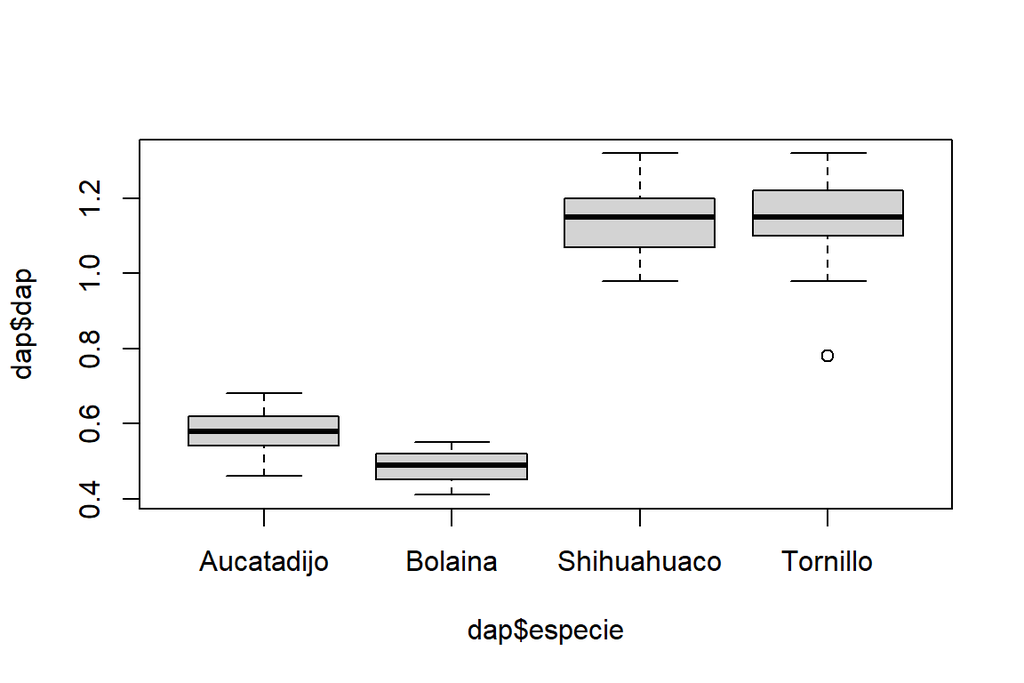

```r
boxplot(dap$dap~dap$especie)
```

*Conclusión*. A un nivel de significancia de 0.01, existe suficiente evidencia estadística para rechazar $H_0$. Por lo tanto, se puede afirmar que la varianza del diámetro a la altura del pecho es diferente el al menos una de las especies.

**Con Altura**

$H_0: \sigma_{Aucatadijo} = \sigma_{Bolaina} = \sigma_{Shihuahuaco} = \sigma_{Tornillo}$

$H_1: \text{Al menos un } \sigma \text{ es diferente a los demás}$

$\alpha = 0.01$

```r
data("bagua")

altura <- bagua %>%
  select(altura,especie) %>%
  filter(especie %in% c("Aucatadijo","Bolaina","Shihuahuaco","Tornillo"))

altura$especie <- altura$especie %>% as.character %>% as.factor

bartlett.test(altura$altura~altura$especie)
```

```
    Bartlett test of homogeneity of variances

data:  altura$altura by altura$especie
Bartlett's K-squared = 0.22799, df = 3, p-value = 0.9729
```

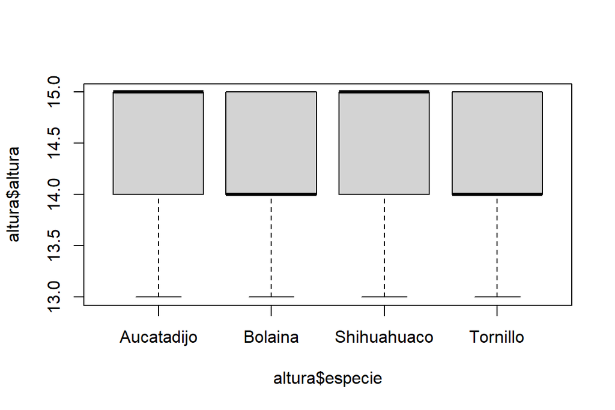

```r
boxplot(altura$altura~altura$especie)
```

*Conclusión*. A un nivel de significancia de 0.01, existe suficiente evidencia estadística para no rechazar $H_0$. Por lo tanto, se puede afirmar que la varianza de la altura del árbol no es diferente entre las especies.

## Prueba de k medias

$H_0: \mu_{Aucatadijo} = \mu_{Bolaina} = \mu_{Shihuahuaco} = \mu_{Tornillo}$

$H_1: \text{Al menos un } \mu \text{ es diferente a los demás}$

$\alpha = 0.07$

Esta prueba tiene como supuesto que la dispersión o varianza de los niveles del factor evaluado es estadísticamente similar entre los niveles.

```r
data("bagua")

summary(aov(lm(altura~especie, altura)))
```

```
             Df Sum Sq Mean Sq F value Pr(>F)
especie       3   1.43  0.4753   1.366  0.253
Residuals   267  92.89  0.3479
```

```r
cat("F tabular al 0.07 de alfa:",qf(0.07,3,267, lower.tail = F),".\n")
```

```
F tabular al 0.07 de alfa: 2.380331 .
```

*Conclusión*. A un nivel de significancia de 0.07, existe suficiente evidencia estadística para no rechazar $H_0$. Por lo tanto puede afirmar que la altura de planta es estadísticamente similar entre las especies “Aucatadijo”, “Bolaina”, “Shihuahuaco” y “Tornillo”.

## Pruebas no paramétricas

### Prueba U de Mann-Whitney

$H_0: Mediana_{Aucatadijo} = Mediana_{Shihuahuaco}$

$H_1: Mediana_{Aucatadijo} \neq Mediana_{Shihuahuaco}$

$\alpha = 0.05$

```r
dap2 <- bagua %>%
  select(dap,especie) %>%
  filter(especie %in% c("Aucatadijo","Shihuahuaco"))

Aucatadijo <- dap2%>%
  filter(especie %in% c("Aucatadijo"))

Shihuahuaco <- dap2%>%
  filter(especie %in% c("Shihuahuaco"))
```

```r
wilcox.exact(Aucatadijo$dap,Shihuahuaco$dap, mu = 0,
            paired = F, alternative = "t")
```

```
    Asymptotic Wilcoxon rank sum test

data:  Aucatadijo$dap and Shihuahuaco$dap
W = 0, p-value < 0.00000000000000022
alternative hypothesis: true mu is not equal to 0
```

*Conclusión*. A un nivel de significancia de 0.05, existe suficiente evidencia estadística para rechazar la $H_0$. Por lo tanto, podemos afirmar que el dap mediano de la especie Aucatadijo es diferente al de la especie Shihuahuaco.

### Prueba Mood

$H_0: \theta_{Aucatadijo} = \theta_{Shihuahuaco}$

$H_1: \theta_{Aucatadijo} \neq \theta_{Shihuahuaco}$

$\alpha = 0.05$

```r
mood.test(Aucatadijo$dap,Shihuahuaco$dap, alternative = "t")
```

```
    Mood two-sample test of scale

data:  Aucatadijo$dap and Shihuahuaco$dap
Z = 1.6134, p-value = 0.1067
alternative hypothesis: two.sided
```

*Conclusión*. A un nivel de significancia de 0.05, existe suficiente evidencia estadística para no rechazar la $H_0$. Por lo tanto, podemos afirmar que la diferencia en la dispersión del diámetro a la altura del pecho de la especie Aucatadijo es igual al de la especie Shihuahuaco.

### Prueba Kruskal Wallis

$H_0: \text{El dap de las especies provienen de la misma distribución}$

$H_1: \text{El dap de las especies no provienen de la misma distribución}$

```r
kSamples::ad.test(dap$dap~dap$especie)
```

```
 Anderson-Darling k-sample test.

Number of samples:  4
Sample sizes:  53, 89, 69, 60
Number of ties: 220

Mean of  Anderson-Darling  Criterion: 3
Standard deviation of  Anderson-Darling  Criterion: 1.30473

T.AD = ( Anderson-Darling  Criterion - mean)/sigma

Null Hypothesis: All samples come from a common population.

            AD  T.AD                                                    asympt. P-value
version 1: 121 90.46 0.0000000000000000000000000000000000000000000000000000000001908000
version 2: 126 94.39 0.0000000000000000000000000000000000000000000000000000000000002719
```

$H_0: Mediana_{Aucatadijo} = Mediana_{Bolaina} = Mediana_{Shihuahuaco} = Mediana_{Tornillo}$

$H_1: \text{Al menos una Mediana es diferente a las demás}$

```r
with(dap,kruskal(y = dap,trt = especie,alpha = 0.05,group = T,console = T))
```

```
Study: dap ~ especie
Kruskal-Wallis test's
Ties or no Ties

Critical Value: 218.2316
Degrees of freedom: 3
Pvalue Chisq  : 0

especie,  means of the ranks

                  dap  r
Aucatadijo  105.54717 53
Bolaina      51.22472 89
Shihuahuaco 206.34783 69
Tornillo    207.75000 60

Post Hoc Analysis

t-Student: 1.968889
Alpha    : 0.05
Groups according to probability of treatment differences and alpha level.

Treatments with the same letter are not significantly different.

                  dap groups
Tornillo    207.75000      a
Shihuahuaco 206.34783      a
Aucatadijo  105.54717      b
Bolaina      51.22472      c
```

### Prueba de la Mediana

$H_0: Mediana_{Aucatadijo} = Mediana_{Bolaina} = Mediana_{Shihuahuaco} = Mediana_{Tornillo}$

$H_1: \text{Al menos una Mediana es diferente a las demás}$

```r
with(dap,Median.test(y = dap,trt = especie,alpha = 0.05,group = T,console = T))
```

```
The Median Test for dap ~ especie

Chi Square = 249.7167   DF = 3   P.Value 0.000000000000000000000000000000000000000000000000000007535327
Median = 0.65

            Median  r  Min  Max  Q25  Q75
Aucatadijo    0.58 53 0.46 0.68 0.54 0.62
Bolaina       0.49 89 0.41 0.55 0.45 0.52
Shihuahuaco   1.15 69 0.98 1.32 1.07 1.20
Tornillo      1.15 60 0.78 1.32 1.10 1.22

Post Hoc Analysis

Groups according to probability of treatment differences and alpha level.

Treatments with the same letter are not significantly different.

             dap groups
Shihuahuaco 1.15      a
Tornillo    1.15      a
Aucatadijo  0.58      b
Bolaina     0.49      c
```